# **Panorama da inflação**

Os principais índices de inflação do Brasil, apontam em dezembro de 2012 um avanço da inflação de em média **0.74%**. Com esse resultado, no ano a inflação acumula uma variação média positiva de **6.53%**, e em 12 meses uma variação média acumulada de **6.62%**.

|  | Variação mensal | Variação acumulada no ano | Variação acumulada em 12 meses |
| --- | --- | --- | --- |
| IPCA | 0.79% | 5.84% | 5.84% |
| INPC | 0.74% | 6.2% | 6.2% |
| IGP-M | 0.68% | 7.55% | 7.82% |
| IGP-DI | 0.66% | 7.77% | 8.1% |
| IPA | 0.74% | 0.09% | 0.09% |
| IPC | 0.66% | 4.89% | 5.74% |
| INCC | 0.16% | 6.17% | 7.12% |

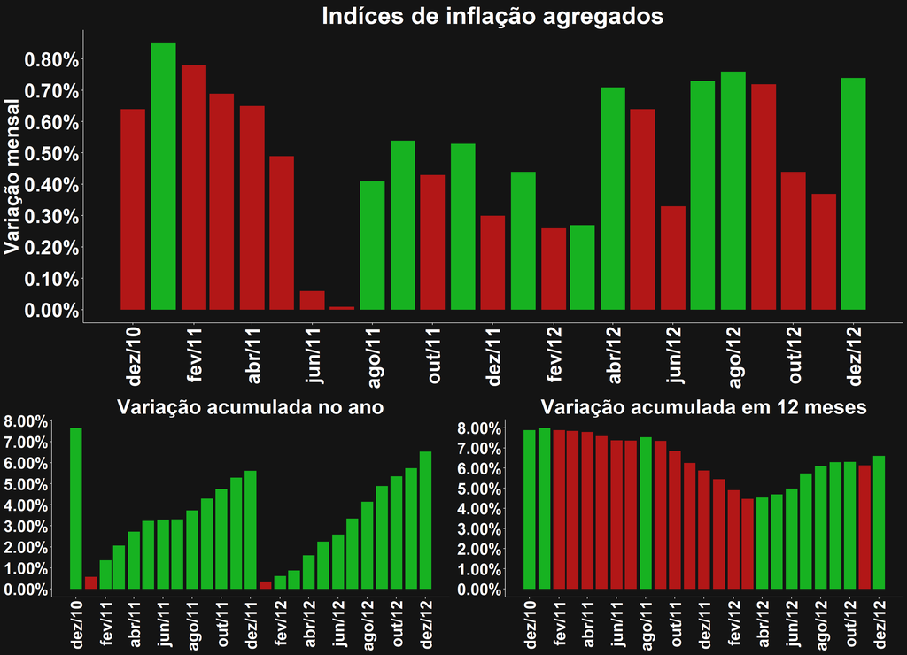

Índices selecionados para a média: IPCA, INPC e IGP-M.

# IPCA

O Indíce de Preços ao Consumidor Amplo (IPCA) variou 0.79% em dezembro, valor superior ao mesmo período do ano anterior quando apresentou uma taxa de 0.5%. Com esse resultado o indíce acumula no ano uma variação positiva de 5.84%, e em 12 meses uma variação positiva de 5.84%.

|  | 12/2011 | 11/2012 | 12/2012 |
| --- | --- | --- | --- |
| Variação mensal | 0.5% | 0.6% | 0.79% |
| Variação acumulada no ano | 6.5% | 5.01% | 5.84% |
| Variação acumulada em 12 meses | 6.5% | 5.53% | 5.84% |

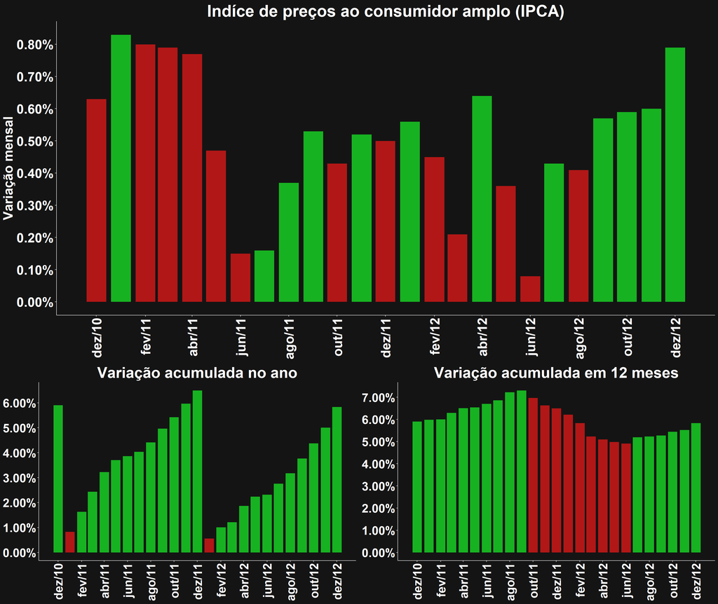

|  | Variação mensal | Variação acumulada no ano | Peso mensal |
| --- | --- | --- | --- |
| Alimentação e bebidas | 1.03% | 9.86% | 23.93% |
| Habitação | 0.63% | 6.81% | 14.77% |
| Artigos de residência | 0.27% | 0.85% | 4.48% |
| Vestuário | 1.11% | 5.8% | 6.64% |
| Transportes | 0.75% | 0.46% | 19.52% |
| Saúde e cuidados pessoais | 0.4% | 5.94% | 11.15% |
| Despesas pessoais | 1.6% | 10.16% | 10.27% |
| Educação | 0.19% | 7.79% | 4.48% |
| Comunicação | 0.03% | 0.76% | 4.76% |

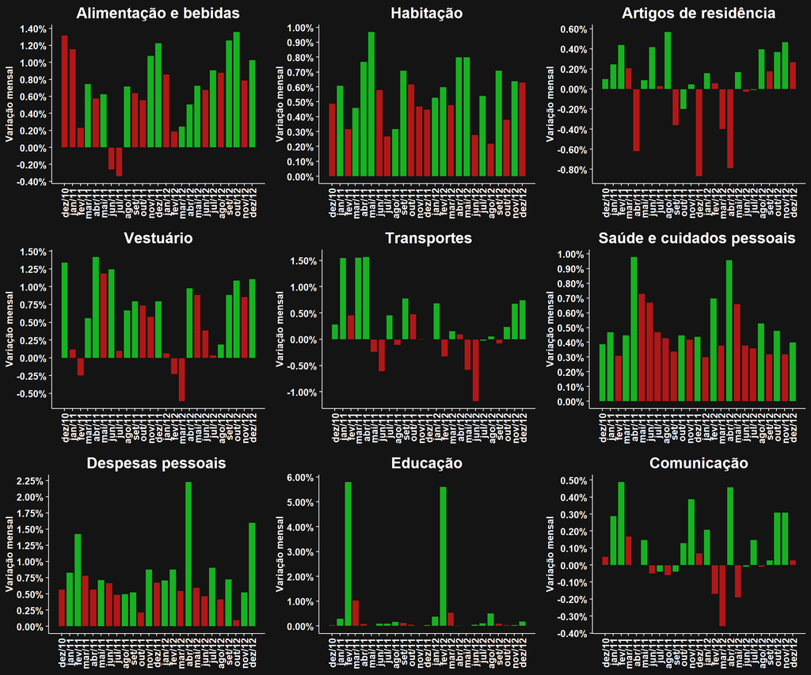

A nível de sub-itens os que mais influenciaram positivamente no resultado em relação ao seu peso foram Passagem aérea (17.12%%) e Excursão (17.13%%), e negativamente Hipotensor e hipocolesterolêmico (-0.87%%) e Uva (-4.82%%).

|  | Variação mensal | Variação acumulada no ano | Peso mensal |
| --- | --- | --- | --- |
| Excursão | 17.13% | 15.25% | 0.37% |
| Passagem aérea | 17.12% | 25.99% | 0.58% |
| Energia elétrica residencial | 1.25% | 2.93% | 3.32% |
| Refeição | 0.74% | 8.62% | 4.93% |

|  | Variação mensal | Variação acumulada no ano | Peso mensal |
| --- | --- | --- | --- |
| Refrigerante e água mineral | -0.35% | 9.82% | 0.72% |
| Hipotensor e hipocolesterolêmico | -0.87% | 4.03% | 0.71% |
| Batata-inglesa | -1.8% | 49.97% | 0.2% |
| Uva | -4.82% | 5.88% | 0.08% |

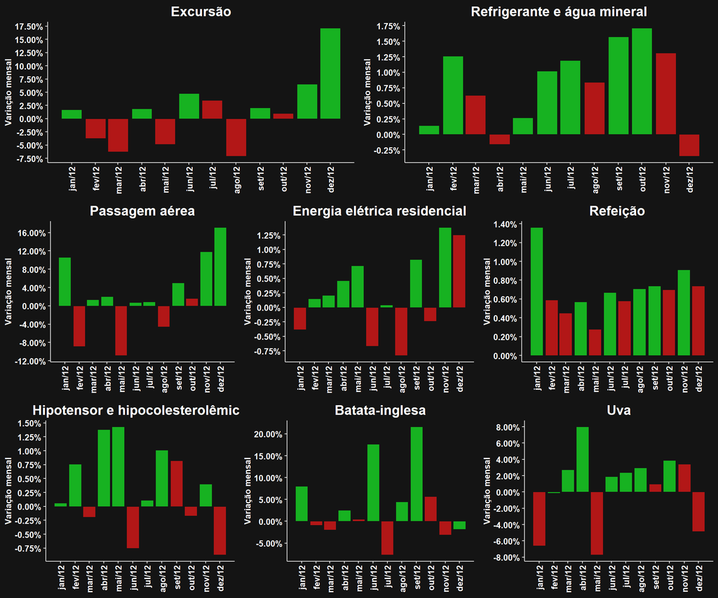

# INPC

O Indíce Nacional de Preços ao Consumidor (INPC) variou 0.74% em dezembro, valor superior ao mesmo período do ano anterior quando apresentou uma taxa de 0.51%. Com esse resultado o indíce acumula no ano uma variação positiva de 6.2%, e em 12 meses uma variação positiva de 6.2%.

|  | 12/2011 | 11/2012 | 12/2012 |
| --- | --- | --- | --- |
| Variação mensal | 0.51% | 0.54% | 0.74% |
| Variação acumulada no ano | 6.08% | 5.42% | 6.2% |
| Variação acumulada em 12 meses | 6.08% | 5.95% | 6.2% |

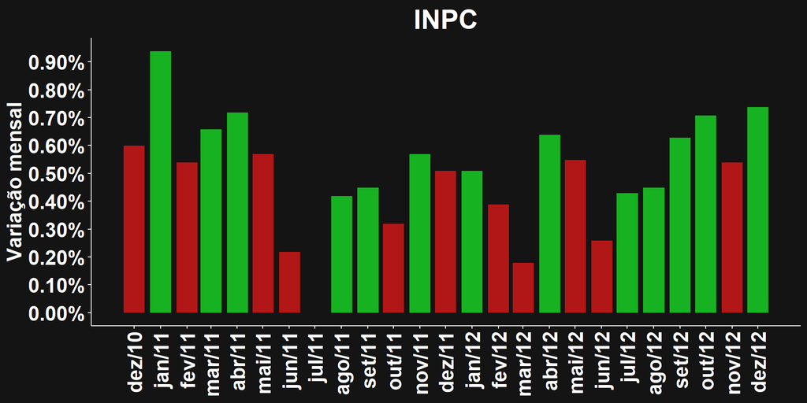

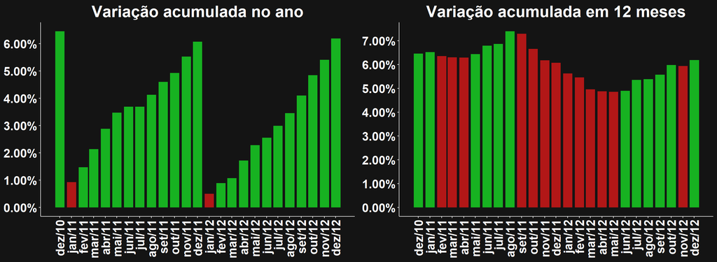

# IGP-M

O Indíce Geral de Preços de Mercado (IGP-M) variou 0.68% em dezembro, valor superior ao mesmo período do ano anterior quando apresentou uma taxa de -0.12%. Com esse resultado o indíce acumula no ano uma variação positiva de 7.55%, e em 12 meses uma variação positiva de 7.82%.

|  | 12/2011 | 11/2012 | 12/2012 |
| --- | --- | --- | --- |
| Variação mensal | -0.12% | -0.03% | 0.68% |
| Variação acumulada no ano | 4.27% | 6.82% | 7.55% |
| Variação acumulada em 12 meses | 5.1% | 6.96% | 7.82% |

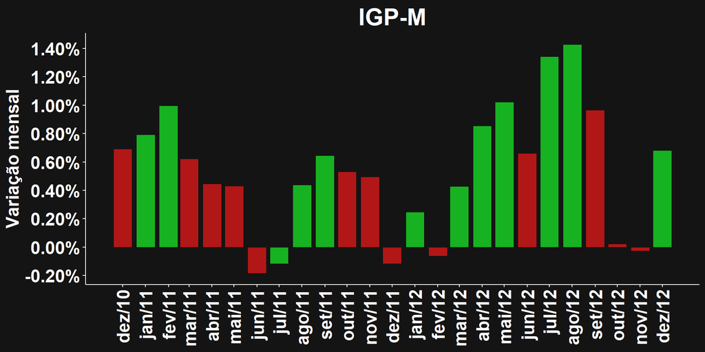

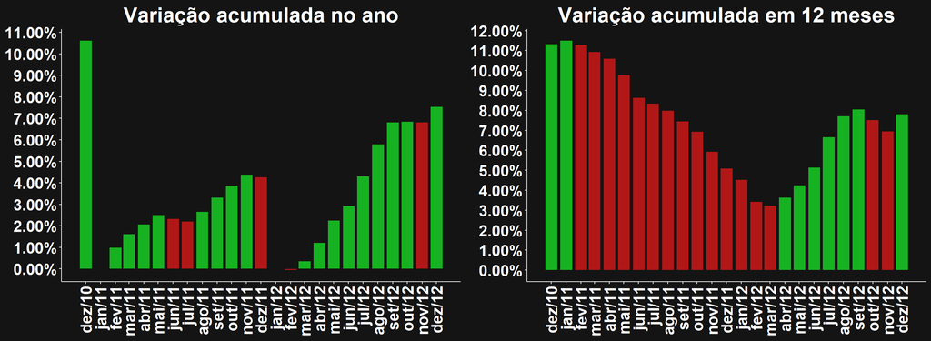

# IGP-DI

O Indíce Geral de Preços - Disponibilidade Interna (IGP-DI) variou 0.66% em dezembro, valor superior ao mesmo período do ano anterior quando apresentou uma taxa de -0.16%. Com esse resultado o indíce acumula no ano uma variação positiva de 7.77%, e em 12 meses uma variação positiva de 8.1%.

|  | 12/2011 | 11/2012 | 12/2012 |
| --- | --- | --- | --- |
| Variação mensal | -0.16% | 0.25% | 0.66% |
| Variação acumulada no ano | 3.98% | 7.07% | 7.77% |
| Variação acumulada em 12 meses | 5% | 7.22% | 8.1% |

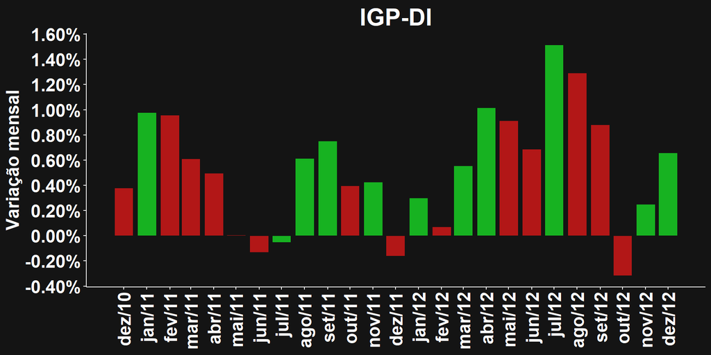

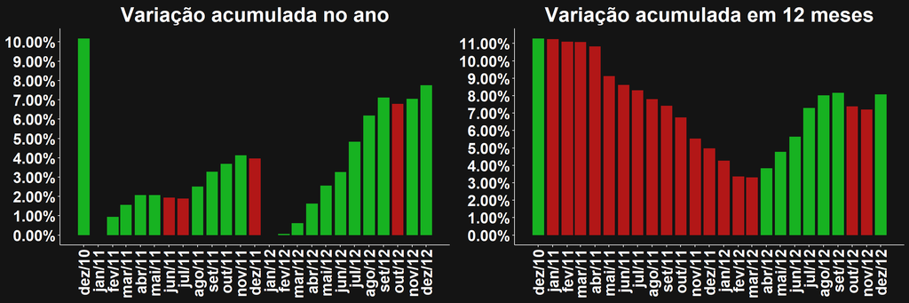

|  | 12/2011 | 11/2012 | 12/2012 |
| --- | --- | --- | --- |
| Variação mensal | -0.55% | 0.16% | 0.74% |
| Variação acumulada no ano | 0.04% | 0.08% | 0.09% |
| Variação acumulada em 12 meses | 0.04% | 0.08% | 0.09% |

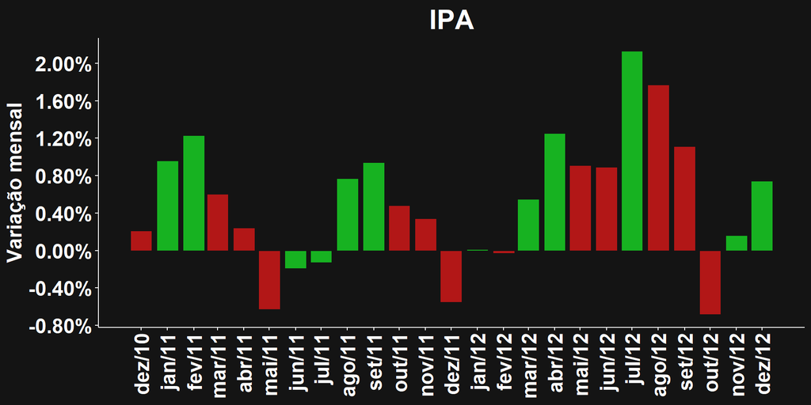

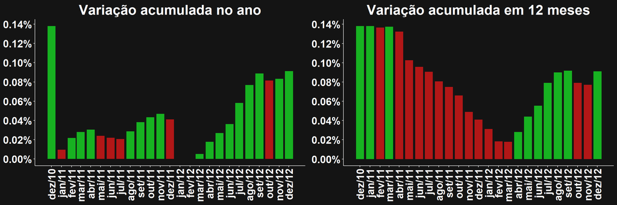

|  | 12/2011 | 11/2012 | 12/2012 |
| --- | --- | --- | --- |
| Variação mensal | 0.79% | 0.45% | 0.66% |
| Variação acumulada no ano | 5.03% | 4.2% | 4.89% |
| Variação acumulada em 12 meses | 6.36% | 5.89% | 5.74% |

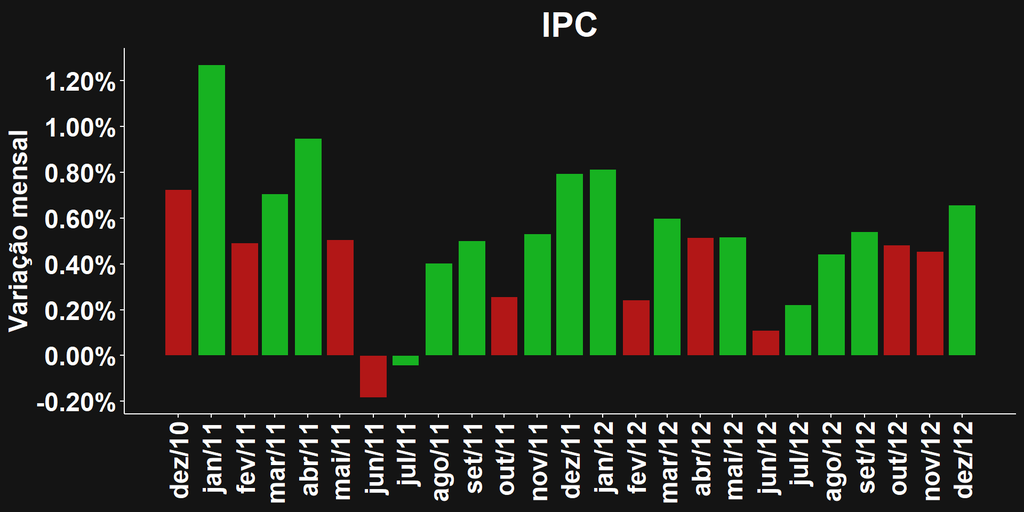

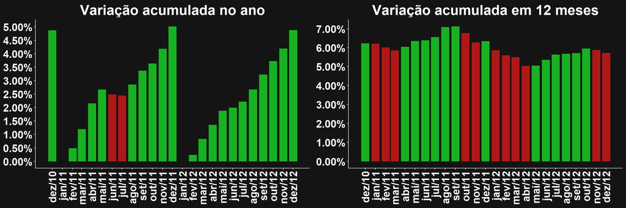

O Indíce Nacional de Custos de Construção (INCC), integrante do IGP-DI com peso de 10%, apresentou variação de 0.16% em dezembro, valor superior ao mesmo período do ano anterior quando apresentou uma taxa de 0.11%. Com esse resultado o indíce acumula no ano uma variação positiva de 6.17%, e em 12 meses uma variação positiva de 7.12%.

|  | 12/2011 | 11/2012 | 12/2012 |
| --- | --- | --- | --- |
| Variação mensal | 0.11% | 0.33% | 0.16% |
| Variação acumulada no ano | 7.05% | 6% | 6.17% |
| Variação acumulada em 12 meses | 7.49% | 7.06% | 7.12% |

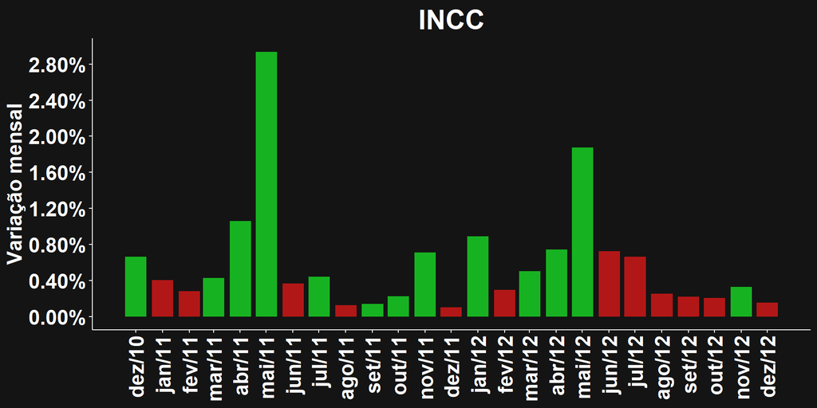

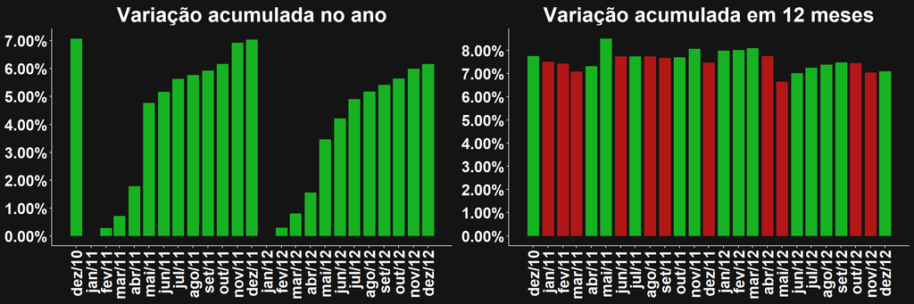

# Estatísticas

As estatísticas descritivas a seguir são feitas com base nos últimos 48 meses, e tem como objetivo possibilitar a avaliação do resultado observado em comparação aos períodos anteriores.

|  | Minimo | 1 Quartil | Mediana | Media | 3 Quartil | Maximo | Desvio Padrão |
| --- | --- | --- | --- | --- | --- | --- | --- |
| IPCA | 0% | 0.34% | 0.47% | 0.46% | 0.59% | 0.83% | 0.23% |
| INPC | -0.11% | 0.26% | 0.51% | 0.46% | 0.64% | 1.03% | 0.27% |
| IGP-M | -0.74% | -0.03% | 0.47% | 0.45% | 0.85% | 1.45% | 0.54% |
| IGP-DI | -0.84% | 0.04% | 0.41% | 0.46% | 0.92% | 1.58% | 0.56% |
| IPA | -1.46% | -0.1% | 0.38% | 0.45% | 0.96% | 2.13% | 0.83% |
| IPC | -0.21% | 0.22% | 0.48% | 0.45% | 0.66% | 1.29% | 0.35% |
| INCC | -0.26% | 0.2% | 0.35% | 0.52% | 0.71% | 2.94% | 0.56% |

Levando em consideração o desvio padrão de cada indíce, proporcionalmente os que mais se afastaram da média foram o IPCA, o INPC e o INCC.

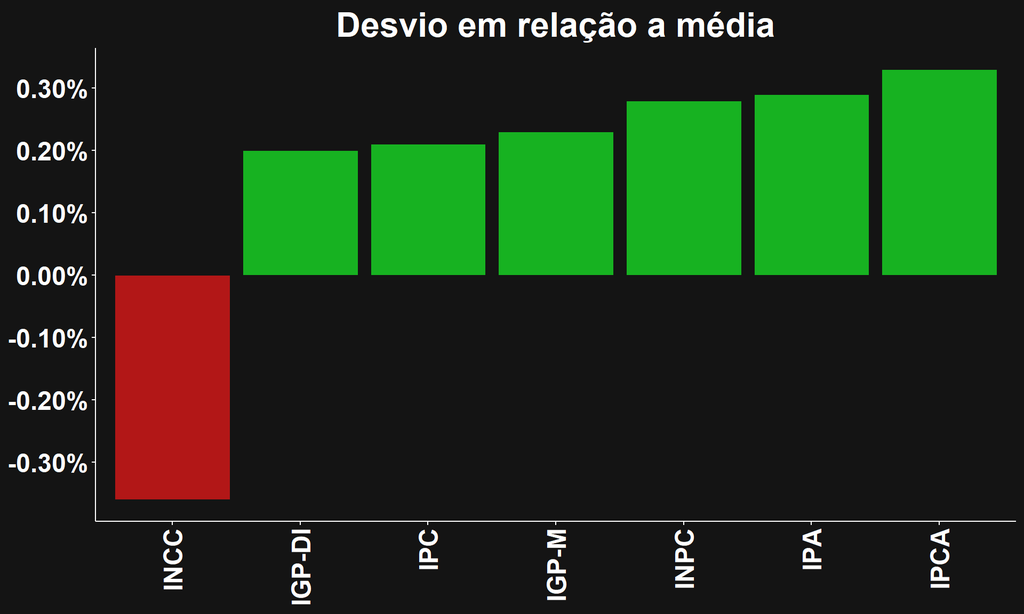

**João Victor Gomes**  
**jvg.santana@gmail.com**  
**[linkedin.com/in/jvictorgomes](https://www.linkedin.com/in/jvictorgomes/)**